# Lab1_Report

Lihe Liu

09 September, 2019

# **ANS6905_Lab1 Simple and Multiple Linear Regression**

## **1.Simple Linear regression**

Now we read in our dataset and check the structure.

```r
str(BodyWeightData_sub)
```

```
## 'data.frame':    48 obs. of  2 variables:
##  $ DMI: num  7.21 9.76 7.97 8.41 12.34 ...
##  $ BW : int  304 280 400 279 372 353 321 368 389 328 ...
```

```r
dim(BodyWeightData_sub) # NO.row goes first
```

```
## [1] 48  2
```

```r
head(BodyWeightData_sub,5) # check the first 5 lines
```

```
##     DMI  BW
## 1  7.21 304
## 2  9.76 280
## 3  7.97 400
## 4  8.41 279
## 5 12.34 372
```

```r
tail(BodyWeightData_sub,5)# check the bottom 5 lines
```

```
##      DMI  BW
## 44  7.95 345
## 45 10.83 412
## 46  8.73 279
## 47  8.47 294
## 48  8.84 363
```

We can we get here? First, We have two continuous variabales, DMI and BW, and we have 48 observations. we can also run dim() function to briefly check the dimensions, the first number 48 is the number of rows (animals, normally) and the second number 2 is the number of columns (traits, normally). Also, run head() or tail() to check the top/bottom n (as you like) lines in the dataset.

Now we plot the data to have a grapical impression.

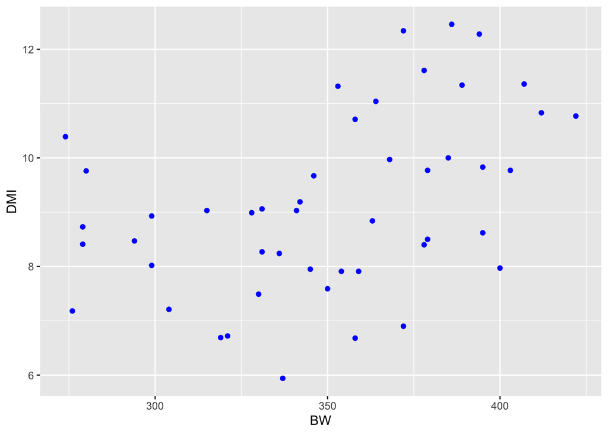

```r
plot_simple_lm = ggplot(data = BodyWeightData_sub,aes(x = BW , y = DMI)) + geom_point(color='blue')
plot_simple_lm
```

Time to fit a simple linear regression model.

```r
#recall our formula (Y = ß0 + ß1 * x + ε)
BW_simple_lm <- lm(DMI ~ BW, # regression formula in R style syntax
                   data= BodyWeightData_sub)
summary(BW_simple_lm)
```

```
##
## Call:
## lm(formula = DMI ~ BW, data = BodyWeightData_sub)
##
## Residuals:
##     Min      1Q  Median      3Q     Max
## -2.9614 -1.1758  0.1568  0.7506  2.8103
##
## Coefficients:
##             Estimate Std. Error t value Pr(>|t|)
## (Intercept) 2.851597   1.910698   1.492  0.14241
## BW          0.017952   0.005432   3.305  0.00185 **
## ---
## Signif. codes:  0 '***' 0.001 '**' 0.01 '*' 0.05 '.' 0.1 ' ' 1
##
## Residual standard error: 1.484 on 46 degrees of freedom
## Multiple R-squared:  0.1919, Adjusted R-squared:  0.1743
## F-statistic: 10.92 on 1 and 46 DF,  p-value: 0.001845
```

Also we have some succinct summary styles.

```r
# version 1
sumary(BW_simple_lm)
```

```
##              Estimate Std. Error t value Pr(>|t|)
## (Intercept) 2.8515974  1.9106980  1.4924 0.142412
## BW          0.0179518  0.0054315  3.3051 0.001845
##
## n = 48, p = 2, Residual SE = 1.48369, R-Squared = 0.19
```

```r
# version 2
coef(BW_simple_lm)
```

```
## (Intercept)          BW
##   2.8515974   0.0179518
```

Now we integrate the predicted value and draw the line again

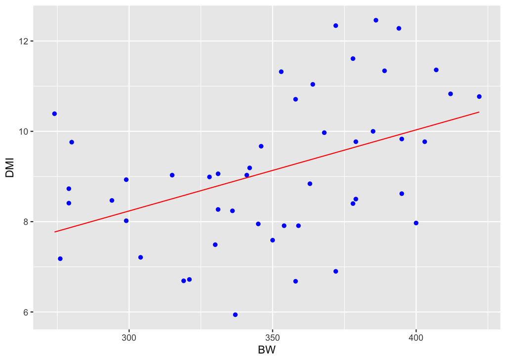

```r
BodyWeightData_sub <- add_column(BodyWeightData_sub, my_prediction = predict(BW_simple_lm))
plot_simple_lm + geom_line(color='red',data = BodyWeightData_sub,aes(x = BW, y= my_prediction))
```

## **2. Matrix Calculations (Simple Linear regression)**

We will be checking the matrix calculations behind the model, and that’s how it functions.  
We go again, we can put the models in another form — matrix format, seems not ituiative, but effective.

```r
x = model.matrix(BW_simple_lm) # Get your model Design Matrix
y = BodyWeightData_sub$DMI # Vector of Responses
# To get x'x
t(x)%*%x
```

```
##             (Intercept)      BW
## (Intercept)          48   16779
## BW                16779 5939927
```

```r
# To get (x'x)^(-1)
xtxi = solve(t(x)%*%x)
# To get x'y
t(x)%*% y
```

```
##                  [,1]
## (Intercept)    438.09
## BW          154479.36
```

Least Squares Estimator: β1 / β0

```r
Beta_hat = xtxi%*%t(x)%*%y
coef(BW_simple_lm) # These come from the functions.
```

```
## (Intercept)          BW
##   2.8515974   0.0179518
```

```r
Beta_hat # These come from the matrix calculations.
```

```
##                  [,1]
## (Intercept) 2.8515974
## BW          0.0179518
```

```r
round(Beta_hat,3) == round(coef(BW_simple_lm),3)# The results would be the SAME!
```

```
##             [,1]
## (Intercept) TRUE
## BW          TRUE
```

Estimation of Residual Variance

```r
y_hat = BodyWeightData_sub$my_prediction
SS_res = sum((y - y_hat)^2)
MSE = SS_res/(NOrow - 2)# an unbiased estimator of σ2
sqrt(MSE) # σ
```

```
## [1] 1.483691
```

```r
sigma_compare = round(summary(BW_simple_lm,)$sigma,3)
sigma_compare  == round(sqrt(MSE),3) # Shoule be the same SAME value.
```

```
## [1] TRUE
```

```r
# Variance-Covariance Matrix --- β^hat
var_cov = xtxi * MSE
sqrt(diag(var_cov)) # SEs of estimates (by hand)
```

```
## (Intercept)          BW
## 1.910698012 0.005431529
```

```r
parameter_SE = summary(BW_simple_lm)$coefficients[,2] # SE of estimates (from lm())
round(sqrt(diag(var_cov)),3) == round(parameter_SE,3)
```

```
## (Intercept)          BW
##        TRUE        TRUE
```

Hypothesis Testing 1: **t-test**  
Testing significance of regression — Ho:β1 = 0; H1: β1 != 0  
Note that here can assume all the assumptions stand!

```r
## t-test
se_beta1_hat = sqrt(diag(var_cov))
t0 = Beta_hat[,1]/se_beta1_hat
simple_lm_coef = summary(BW_simple_lm)$coefficients
simple_lm_coef[,3] #locate t value, it's in the third column
```

```
## (Intercept)          BW
##    1.492438    3.305111
```

```r
t0 # compare with t0 we got from the matrix
```

```
## (Intercept)          BW
##    1.492438    3.305111
```

Hypothesis Testing 2: **F-test** Testing significance of regression — Ho:β1 = 0; H1: β1 != 0  
Analysis of variance (SS_T = SS_reg + SS_res)  
Note that here can assume all the assumptions stand!

```r
SS_reg = sum((predict(BW_simple_lm)-mean(y))^2)
SS_res = sum((y - y_hat)^2)
F0 = ((SS_reg)/(2-1))/MSE
F0
```

```
## [1] 10.92376
```

```r
summary(BW_simple_lm)
```

```
##
## Call:
## lm(formula = DMI ~ BW, data = BodyWeightData_sub)
##
## Residuals:
##     Min      1Q  Median      3Q     Max
## -2.9614 -1.1758  0.1568  0.7506  2.8103
##
## Coefficients:
##             Estimate Std. Error t value Pr(>|t|)
## (Intercept) 2.851597   1.910698   1.492  0.14241
## BW          0.017952   0.005432   3.305  0.00185 **
## ---
## Signif. codes:  0 '***' 0.001 '**' 0.01 '*' 0.05 '.' 0.1 ' ' 1
##
## Residual standard error: 1.484 on 46 degrees of freedom
## Multiple R-squared:  0.1919, Adjusted R-squared:  0.1743
## F-statistic: 10.92 on 1 and 46 DF,  p-value: 0.001845
```

Coefficient of Determination (R^2), measuring the goodness of fit.  
It is the proportion of the variance in the dependent variable that is predictable from the independent variable(s).

```r
R2 = SS_reg/(SS_reg + SS_res)
round(R2,3) == round(summary(BW_simple_lm)$`r.squared`,3)
```

```
## [1] TRUE
```

```r
R2_adj= 1 -((SS_res/(NOrow - 2))/((SS_reg + SS_res)/(NOrow - 1)))
round(R2_adj,3) == round(summary(BW_simple_lm)$`adj.r.squared`,3)
```

```
## [1] TRUE
```

```r
# Check the anova table and you will get the same value/conclusions
anova(BW_simple_lm)
```

```
## Analysis of Variance Table
##
## Response: DMI
##           Df  Sum Sq Mean Sq F value   Pr(>F)
## BW         1  24.047 24.0469  10.924 0.001845 **
## Residuals 46 101.262  2.2013
## ---
## Signif. codes:  0 '***' 0.001 '**' 0.01 '*' 0.05 '.' 0.1 ' ' 1
```

## **3.Multiple Linear Regression - part1**

We will be using a new dataset - Italian Restaurant.  
We can check the raw dataset by runing the simple functions mentioned above.

```r
str(ItaRestaurants)
```

```
## 'data.frame':    168 obs. of  4 variables:
##  $ Price  : int  43 32 34 41 54 52 34 34 39 44 ...
##  $ Food   : int  22 20 21 20 24 22 22 20 22 21 ...
##  $ Decor  : int  18 19 13 20 19 22 16 18 19 17 ...
##  $ Service: int  20 19 18 17 21 21 21 21 22 19 ...
```

```r
summary(ItaRestaurants) # if they are continuous we can run summary() to better know the data
```

```
##      Price           Food          Decor          Service
##  Min.   :19.0   Min.   :16.0   Min.   : 6.00   Min.   :14.0
##  1st Qu.:36.0   1st Qu.:19.0   1st Qu.:16.00   1st Qu.:18.0
##  Median :43.0   Median :20.5   Median :18.00   Median :20.0
##  Mean   :42.7   Mean   :20.6   Mean   :17.69   Mean   :19.4
##  3rd Qu.:50.0   3rd Qu.:22.0   3rd Qu.:19.00   3rd Qu.:21.0
##  Max.   :65.0   Max.   :25.0   Max.   :25.00   Max.   :24.0
```

```r
dim(ItaRestaurants)
```

```
## [1] 168   4
```

```r
head(ItaRestaurants) # check/show some lines, default value is 6 (lines to view)
```

```
##   Price Food Decor Service
## 1    43   22    18      20
## 2    32   20    19      19
## 3    34   21    13      18
## 4    41   20    20      17
## 5    54   24    19      21
## 6    52   22    22      21
```

We can plot each variable against each other, try to figure out the relationships between them.

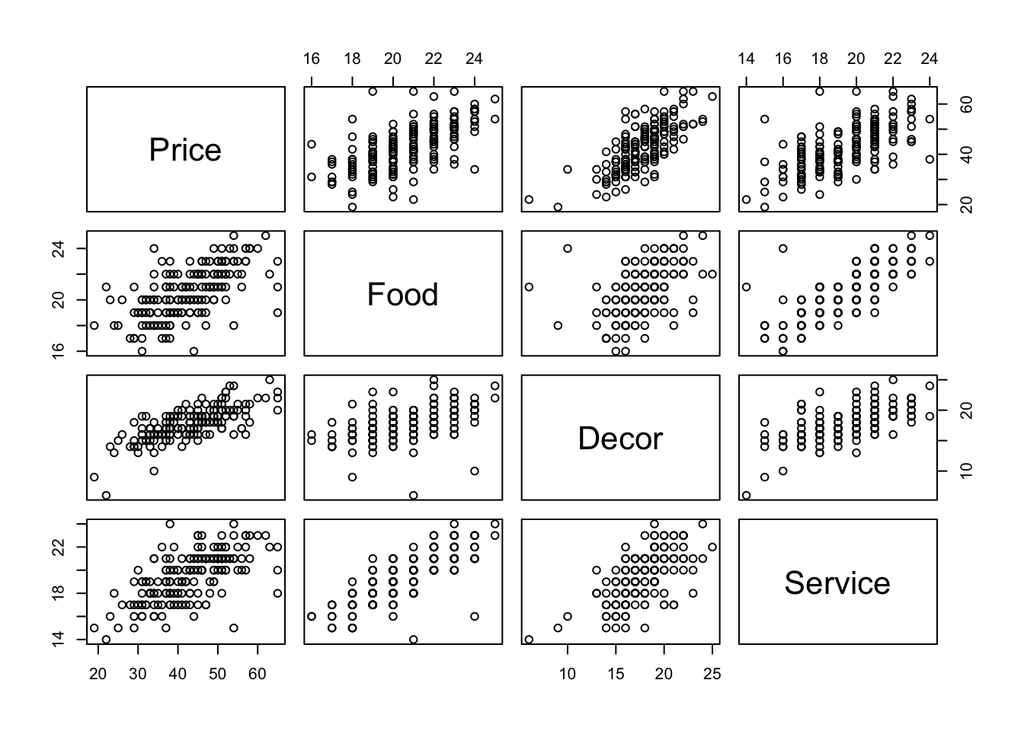

```r
plot(ItaRestaurants)
```

Now we fit a linear model.

```r
#recall our formula (Y = ß0 + ß1*x1, ß2*x2, ß3*x3 + ε)
ItaRes_multi_lm <- lm(Price ~ Food + Decor + Service,
                      data = ItaRestaurants)
summary(ItaRes_multi_lm)
```

```
##
## Call:
## lm(formula = Price ~ Food + Decor + Service, data = ItaRestaurants)
##
## Residuals:
##      Min       1Q   Median       3Q      Max
## -14.8440  -3.7039  -0.1525   3.6218  19.0576
##
## Coefficients:
##             Estimate Std. Error t value Pr(>|t|)
## (Intercept) -24.6409     4.7536  -5.184 6.33e-07 ***
## Food          1.5556     0.3731   4.170 4.93e-05 ***
## Decor         1.8473     0.2176   8.491 1.17e-14 ***
## Service       0.1350     0.3957   0.341    0.733
## ---
## Signif. codes:  0 '***' 0.001 '**' 0.01 '*' 0.05 '.' 0.1 ' ' 1
##
## Residual standard error: 5.803 on 164 degrees of freedom
## Multiple R-squared:  0.617,  Adjusted R-squared:   0.61
## F-statistic: 88.06 on 3 and 164 DF,  p-value: < 2.2e-16
```

```r
# succinct version 1 --- sumary(ItaRes_multi_lm)
# succinct version 2 --- coef(ItaRes_multi_lm)
```

Contour plot: For better illustration, we just drop one of the predictors - service

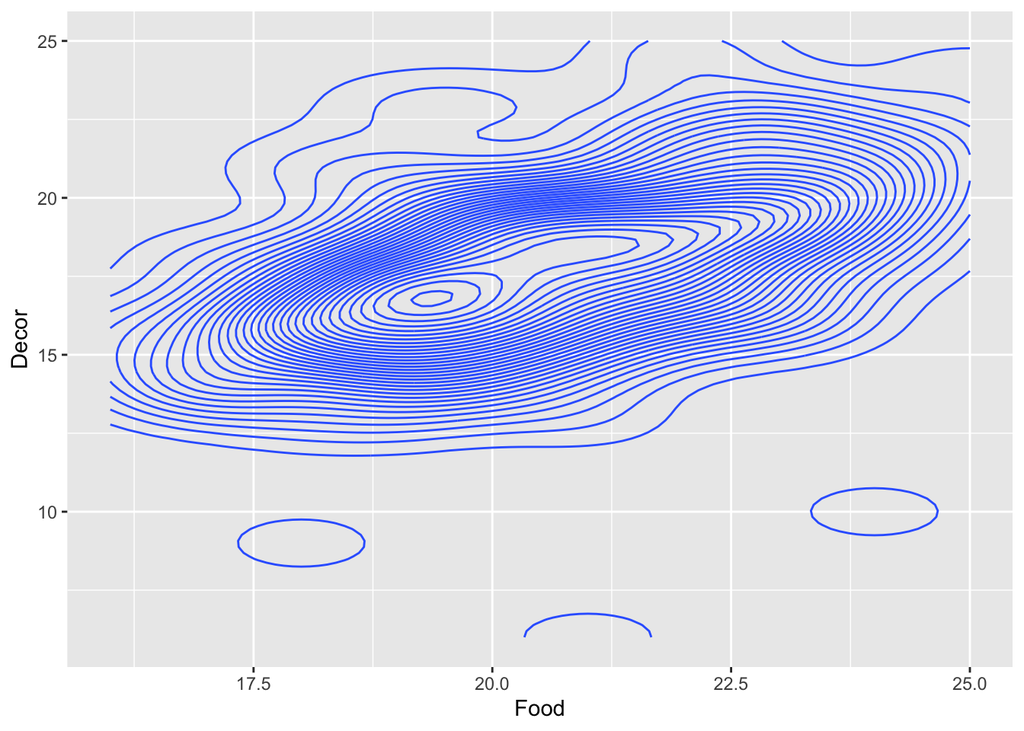

```r
ItaRes_coutour = ggplot(ItaRes_multi_lm, aes(Food, Decor, z = Price)) +
geom_density_2d(binwidth = 0.001)
ItaRes_coutour
```

[output not shown]

[output not shown]

[output not shown]

[output not shown]

[output not shown]

[output not shown]

[output not shown]

[output not shown]

[output not shown]

[output not shown]

[output not shown]

[output not shown]

[output not shown]

[output not shown]

Hypothesis Testing : **t-test** for individual regression coefficient  
Testing significance of regression — Ho:β1 = 0; Ho:β1 != 0  
Note that here can assume all the assumptions stand!

```r
# For example, we try the predictor “Food”
se_beta1_hat_food = sqrt(diag(var_cov_Ita))[2]
se_beta1_hat_food
```

```
##      Food
## 0.3730821
```

```r
t0_food = Beta_hat_Ita[2,1]/se_beta1_hat_food
t0_food
```

```
##     Food
## 4.169515
```

```r
sumary(ItaRes_multi_lm)
```

```
##              Estimate Std. Error t value  Pr(>|t|)
## (Intercept) -24.64090    4.75361 -5.1836 6.333e-07
## Food          1.55557    0.37308  4.1695 4.933e-05
## Decor         1.84734    0.21755  8.4914 1.171e-14
## Service       0.13505    0.39565  0.3413    0.7333
##
## n = 168, p = 4, Residual SE = 5.80350, R-Squared = 0.62
```

Confidence Intervals (CIs)  
1. By hand  
2. Use function

```r
#Get critical value 1.974535 prior to calculations, at the signicical level of 0.05
lower = Beta_hat_Ita + c(-1) * 1.974535 * sqrt(diag(var_cov_Ita))
upper = Beta_hat_Ita + c(1) * 1.974535 * sqrt(diag(var_cov_Ita))
cbind(estimates = summary(ItaRes_multi_lm)$coefficients[,1],
      upper = lower,
      lower = upper)
```

```
##               estimates
## (Intercept) -24.6408955 -34.0270674 -15.2547236
## Food          1.5555712   0.8189076   2.2922349
## Decor         1.8473352   1.4177673   2.2769030
## Service       0.1350457  -0.6461841   0.9162755
```

```r
Confint(ItaRes_multi_lm,level=0.95) # Or simply try to use the function
```

```
##                Estimate       2.5 %      97.5 %
## (Intercept) -24.6408955 -34.0270654 -15.2547257
## Food          1.5555712   0.8189078   2.2922347
## Decor         1.8473352   1.4177674   2.2769029
## Service       0.1350457  -0.6461839   0.9162753
```

```r
# We will surely get the same value.
```

Hypothesis Testing 2: **F test** for significance of regression  
Analysis of variance

```r
SS_reg_Ita = sum((predict(ItaRes_multi_lm)-mean(y_Ita))^2)
SS_res_Ita = sum((y_Ita - y_hat_Ita)^2)
F0_ItaRes = (SS_reg_Ita/(4-1))/MSE_Ita
round(F0_ItaRes,3) == round(summary(ItaRes_multi_lm)$fstatistic[1],3)
```

```
## value
##  TRUE
```

```r
# Coefficient of Determination (R^2)
R2_Ita = SS_reg_Ita/(SS_reg_Ita + SS_res_Ita)
round(R2_Ita,3) == round(summary(ItaRes_multi_lm)$`r.squared`,3)
```

```
## [1] TRUE
```

```r
R2_adj_Ita= 1 -((SS_res_Ita/(NOrow_ItaRes - 4))/((SS_reg_Ita + SS_res_Ita)/(NOrow_ItaRes - 1)))
round(R2_adj_Ita,3) == round(summary(ItaRes_multi_lm)$`adj.r.squared`,3)
```

```
## [1] TRUE
```

```r
# anova
anova(ItaRes_multi_lm)
```

```
## Analysis of Variance Table
##
## Response: Price
##            Df Sum Sq Mean Sq  F value Pr(>F)
## Food        1 5670.3  5670.3 168.3552 <2e-16 ***
## Decor       1 3223.7  3223.7  95.7130 <2e-16 ***
## Service     1    3.9     3.9   0.1165 0.7333
## Residuals 164 5523.6    33.7
## ---
## Signif. codes:  0 '***' 0.001 '**' 0.01 '*' 0.05 '.' 0.1 ' ' 1
```

## **4. Multiple Linear Regression - part2**

Regression models using qualitative/categorical variables.(dummy/indicator/binary variable)  
**Continue with our Cow BW Case**  
Now we have more variables, including categorical variables.

```r
str(BodyWeightData)
```

```
## 'data.frame':    48 obs. of  4 variables:
##  $ DMI : num  7.21 9.76 7.97 8.41 12.34 ...
##  $ BW  : int  304 280 400 279 372 353 321 368 389 328 ...
##  $ Diet: Factor w/ 2 levels "HC","LC": 2 2 1 2 2 2 2 2 1 2 ...
##  $ Trt : Factor w/ 3 levels "0","0.5","1": 1 2 1 1 3 1 2 1 2 3 ...
```

```r
summary(BodyWeightData)
```

```
##       DMI               BW        Diet     Trt
##  Min.   : 5.940   Min.   :274.0   HC:24   0  :16
##  1st Qu.: 7.965   1st Qu.:326.2   LC:24   0.5:16
##  Median : 8.960   Median :353.5           1  :16
##  Mean   : 9.127   Mean   :349.6
##  3rd Qu.:10.098   3rd Qu.:379.0
##  Max.   :12.460   Max.   :422.0
```

Now we have dummy variables:  
**Diet** — HC & LC (two levels)  
**Trt** — 0/0.5/1 (three levels)

```r
#recall our formula (Y = ß0 + ß1 * x1 + ß2 * x2 + ß3 * x3  + ε)
BW_categ_lm_full <- lm(DMI ~ BW + Diet + Trt,
                   data= BodyWeightData)
summary(BW_categ_lm_full)
```

```
##
## Call:
## lm(formula = DMI ~ BW + Diet + Trt, data = BodyWeightData)
##
## Residuals:
##      Min       1Q   Median       3Q      Max
## -2.67614 -1.10607 -0.00919  0.90884  2.87624
##
## Coefficients:
##              Estimate Std. Error t value Pr(>|t|)
## (Intercept)  3.036727   2.028799   1.497  0.14175
## BW           0.017717   0.005585   3.172  0.00279 **
## DietLC      -0.391076   0.438326  -0.892  0.37725
## Trt0.5       0.050360   0.538675   0.093  0.92595
## Trt1         0.227539   0.536466   0.424  0.67357
## ---
## Signif. codes:  0 '***' 0.001 '**' 0.01 '*' 0.05 '.' 0.1 ' ' 1
##
## Residual standard error: 1.517 on 43 degrees of freedom
## Multiple R-squared:  0.2102, Adjusted R-squared:  0.1367
## F-statistic:  2.86 on 4 and 43 DF,  p-value: 0.03458
```

```r
# We fit a nested model without Diet (for Partial F test)
BW_categ_lm_nested <- lm(DMI ~ BW + Trt ,
                       data= BodyWeightData)
```

Hypothesis Testing 1: **Partial F test** for significance of regression  
Extra-sum-of-squares method for individual predictor

Two ways:  
1.Calculate by hand (we love old school)  
2.anova() function

```r
# 1. calculations
SS_reg_diff = sum((predict(BW_categ_lm_full) - mean(BodyWeightData$DMI))^2) - sum((predict(BW_categ_lm_nested) - mean(BodyWeightData$DMI))^2)
SS_res_full = sum((BodyWeightData$DMI - predict(BW_categ_lm_full))^2)
F0_p = (SS_reg_diff/(2-1))/(SS_res_full/(48 - 5))
# comparing (use anova() funciton: put two models into one comparison-function)
round(F0_p,3) == round(anova(BW_categ_lm_full,BW_categ_lm_nested)$`F`[2],3)
```

```
## [1] TRUE
```

```r
# 2. relation to t-value
abs(summary(BW_categ_lm_full)$coefficients[3,3])# locate the t value of DIetLC
```

```
## [1] 0.892203
```

```r
sqrt(anova(BW_categ_lm_full,BW_categ_lm_nested)$'F'[2])
```

```
## [1] 0.892203
```

Check the square root of the F value of the partial F test, it’s the same as t value.

Here we mention two small topics, get the CIs of each estimate, and reset the refence level/group for the dummy variables

```r
# 1. Get confidence interval using Confint()
Confint(BW_categ_lm_full)
```

```
##                Estimate        2.5 %     97.5 %
## (Intercept)  3.03672675 -1.054736363 7.12818986
## BW           0.01771658  0.006452503 0.02898066
## DietLC      -0.39107596 -1.275045015 0.49289309
## Trt0.5       0.05035968 -1.035981264 1.13670062
## Trt1         0.22753945 -0.854346840 1.30942574
```

```r
# 2. reset reference group
# now reset the ref
BodyWeightData_new_ref <- within(BodyWeightData,Diet <-relevel(Diet,ref = "LC"))
# re-fit a model
BW_categ_lm_new_ref <- lm(DMI ~ BW  + Diet + Trt,
                          data= BodyWeightData_new_ref)
rownames(summary(BW_categ_lm_full)$coefficients)
```

```
## [1] "(Intercept)" "BW"          "DietLC"      "Trt0.5"      "Trt1"
```

```r
rownames(summary(BW_categ_lm_new_ref)$coefficients)
```

```
## [1] "(Intercept)" "BW"          "DietHC"      "Trt0.5"      "Trt1"
```

Since we are familiar with the theory behind. Here I just demostrate how to get marginal sum of squares.

```r
# marginal sum of squares vs sequential sum of squares
Anova(BW_categ_lm_full, type=3);anova(BW_categ_lm_full)
```

```
## Anova Table (Type III tests)
##
## Response: DMI
##             Sum Sq Df F value   Pr(>F)
## (Intercept)  5.157  1  2.2404 0.141747
## BW          23.158  1 10.0612 0.002793 **
## Diet         1.832  1  0.7960 0.377250
## Trt          0.457  2  0.0993 0.905701
## Residuals   98.973 43
## ---
## Signif. codes:  0 '***' 0.001 '**' 0.01 '*' 0.05 '.' 0.1 ' ' 1
```

```
## Analysis of Variance Table
##
## Response: DMI
##           Df Sum Sq Mean Sq F value  Pr(>F)
## BW         1 24.047 24.0469 10.4474 0.00236 **
## Diet       1  1.831  1.8312  0.7956 0.37738
## Trt        2  0.457  0.2285  0.0993 0.90570
## Residuals 43 98.973  2.3017
## ---
## Signif. codes:  0 '***' 0.001 '**' 0.01 '*' 0.05 '.' 0.1 ' ' 1
```

```r
# marginal sum of squares vs sequential sum of squares
Anova(ItaRes_multi_lm, type=3);anova(ItaRes_multi_lm)
```

```
## Anova Table (Type III tests)
##
## Response: Price
##             Sum Sq  Df F value    Pr(>F)
## (Intercept)  905.0   1 26.8699 6.333e-07 ***
## Food         585.5   1 17.3849 4.933e-05 ***
## Decor       2428.5   1 72.1037 1.171e-14 ***
## Service        3.9   1  0.1165    0.7333
## Residuals   5523.6 164
## ---
## Signif. codes:  0 '***' 0.001 '**' 0.01 '*' 0.05 '.' 0.1 ' ' 1
```

```
## Analysis of Variance Table
##
## Response: Price
##            Df Sum Sq Mean Sq  F value Pr(>F)
## Food        1 5670.3  5670.3 168.3552 <2e-16 ***
## Decor       1 3223.7  3223.7  95.7130 <2e-16 ***
## Service     1    3.9     3.9   0.1165 0.7333
## Residuals 164 5523.6    33.7
## ---
## Signif. codes:  0 '***' 0.001 '**' 0.01 '*' 0.05 '.' 0.1 ' ' 1
```